# Lab1AnalisisPCA

Diego Alegria 15171, Ayleen Rubio 19003, Andrés Say 19705, Mario Sarmientos 17055

23/7/2021

## Análisis Exploratorio

A continuación se mostrará un resumen de cada una de las variables y el tipo

## Datos y variables generales de consumo

```
##        X              Anio           Mes         GasolinaSuper
##  Min.   :  3.0   Min.   :2000   Min.   : 1.000   Min.   :300243
##  1st Qu.: 72.0   1st Qu.:2005   1st Qu.: 3.000   1st Qu.:379833
##  Median :232.0   Median :2010   Median : 6.000   Median :409111
##  Mean   :257.4   Mean   :2010   Mean   : 6.432   Mean   :443338
##  3rd Qu.:416.0   3rd Qu.:2016   3rd Qu.: 9.000   3rd Qu.:516487
##  Max.   :613.0   Max.   :2021   Max.   :12.000   Max.   :760695
##
##  GasolinaRegular  TotalGasolinas        Diesel           DieselLS
##  Min.   :160742   Min.   : 464790   Min.   : 507663   Min.   : 782328
##  1st Qu.:211153   1st Qu.: 597008   1st Qu.: 672193   1st Qu.: 973358
##  Median :261013   Median : 670124   Median : 738942   Median :1072874
##  Mean   :330491   Mean   : 773828   Mean   : 770919   Mean   :1075158
##  3rd Qu.:453665   3rd Qu.: 979125   3rd Qu.: 848871   3rd Qu.:1175725
##  Max.   :768193   Max.   :1528889   Max.   :1216423   Max.   :1417535
##                                     NA's   :41        NA's   :216
##    DieselULS      TotalDiesel           GLP         GasolinaAviacion
##  Min.   : 4100   Min.   : 507663   Min.   :167818   Min.   :   0.01
##  1st Qu.: 8054   1st Qu.: 684439   1st Qu.:223830   1st Qu.:1000.00
##  Median : 9041   Median : 778954   Median :250903   Median :1213.01
##  Mean   : 9710   Mean   : 821005   Mean   :283795   Mean   :1227.12
##  3rd Qu.:10508   3rd Qu.: 925431   3rd Qu.:355234   3rd Qu.:1459.11
##  Max.   :16475   Max.   :1428043   Max.   :686530   Max.   :2734.00
##  NA's   :216                                        NA's   :1
##     Kerosina           TurboJet         Bunker          Asfalto
##  Min.   :   10.89   Min.   : 7358   Min.   : 33606   Min.   : 2288
##  1st Qu.: 6271.10   1st Qu.:36043   1st Qu.:200718   1st Qu.:17238
##  Median :12796.60   Median :41451   Median :320349   Median :25226
##  Mean   :22171.33   Mean   :43141   Mean   :322939   Mean   :27177
##  3rd Qu.:42700.71   3rd Qu.:50337   3rd Qu.:415456   3rd Qu.:34587
##  Max.   :70821.94   Max.   :79675   Max.   :697862   Max.   :77017
##  NA's   :6          NA's   :60
##     PetCoke       AceitesLubricantes GrasasLubricantes   Solventes
##  Min.   : 10383   Min.   :13476      Min.   :236.4     Min.   : 6144
##  1st Qu.: 81065   1st Qu.:18855      1st Qu.:347.8     1st Qu.: 7673
##  Median : 99751   Median :20427      Median :394.4     Median : 8888
##  Mean   :124242   Mean   :20726      Mean   :420.4     Mean   : 9417
##  3rd Qu.:121594   3rd Qu.:22579      3rd Qu.:509.0     3rd Qu.:10884
##  Max.   :366964   Max.   :28854      Max.   :709.2     Max.   :13958
##  NA's   :49       NA's   :228        NA's   :228       NA's   :228
##      Naftas           Ceras        CrudoNacional        Butano
##  Min.   :  0.77   Min.   : 25.75   Min.   :  7770   Min.   :28.88
##  1st Qu.: 14.84   1st Qu.: 31.04   1st Qu.: 37205   1st Qu.:51.97
##  Median : 30.77   Median :160.00   Median : 45686   Median :59.88
##  Mean   : 53.17   Mean   :398.03   Mean   : 53465   Mean   :61.52
##  3rd Qu.: 56.55   3rd Qu.:809.55   3rd Qu.: 60586   3rd Qu.:69.88
##  Max.   :286.57   Max.   :919.24   Max.   :135670   Max.   :89.72
##  NA's   :229      NA's   :250      NA's   :24       NA's   :210
##    Orimulsion     MezclasOleosas       Total
##  Min.   :  1471   Min.   :  83.0   Min.   :1673279
##  1st Qu.:140288   1st Qu.: 829.5   1st Qu.:2099315
##  Median :160121   Median :1928.1   Median :2320872
##  Mean   :142794   Mean   :1657.5   Mean   :2452849
##  3rd Qu.:172099   3rd Qu.:2525.6   3rd Qu.:2739860
##  Max.   :184302   Max.   :3134.8   Max.   :3922257
##  NA's   :229      NA's   :237
```

```
## 'data.frame':    257 obs. of  27 variables:
##  $ X                 : int  3 4 5 6 7 8 9 10 11 12 ...
##  $ Anio              : int  2000 2000 2000 2000 2000 2000 2000 2000 2000 2000 ...
##  $ Mes               : int  1 2 3 4 5 6 7 8 9 10 ...
##  $ GasolinaSuper     : num  308157 307766 331910 315648 319668 ...
##  $ GasolinaRegular   : num  202645 205531 229500 210680 208164 ...
##  $ TotalGasolinas    : num  510802 513297 561410 526328 527832 ...
##  $ Diesel            : num  634667 642381 699807 586804 656948 ...
##  $ DieselLS          : num  NA NA NA NA NA NA NA NA NA NA ...
##  $ DieselULS         : num  NA NA NA NA NA NA NA NA NA NA ...
##  $ TotalDiesel       : num  634667 642381 699807 586804 656948 ...
##  $ GLP               : num  194410 174711 189234 174331 191745 ...
##  $ GasolinaAviacion  : num  1426 1458 1503 1561 1642 ...
##  $ Kerosina          : num  64026 62660 61362 61814 54098 ...
##  $ TurboJet          : num  NA NA NA NA NA NA NA NA NA NA ...
##  $ Bunker            : num  296767 328116 368590 396300 449369 ...
##  $ Asfalto           : num  48446 50597 27593 53794 60137 ...
##  $ PetCoke           : num  NA NA NA NA NA NA NA NA NA NA ...
##  $ AceitesLubricantes: num  NA NA NA NA NA NA NA NA NA NA ...
##  $ GrasasLubricantes : num  NA NA NA NA NA NA NA NA NA NA ...
##  $ Solventes         : num  NA NA NA NA NA NA NA NA NA NA ...
##  $ Naftas            : num  NA NA NA NA NA NA NA NA NA NA ...
##  $ Ceras             : num  NA NA NA NA NA NA NA NA NA NA ...
##  $ CrudoNacional     : num  NA NA NA NA NA NA NA NA NA NA ...
##  $ Butano            : num  NA NA NA NA NA NA NA NA NA NA ...
##  $ Orimulsion        : int  NA NA NA NA NA NA NA NA NA NA ...
##  $ MezclasOleosas    : num  NA NA NA NA NA NA NA NA NA NA ...
##  $ Total             : num  1750545 1773220 1909499 1800933 1941772 ...
```

```
##
## integer numeric
##       4      23
```

El dataset de consumo de combustible tiene 27 variables, de las cuales 4 son de tipo entera y 23 son numéricas. Se puede encontrar variables temporales como el mes y el año, desde 2000 a 2021 (que como son int representan numéricamente cada una de ellas). Las unidades por barriles de cada tipo de gasolina: GasolinaSuper, GasolinaRegular,TotalGasolinas,Diesel,DieselLS,Diesel,ULS, GLP (combustible alternativo: gas licuado de petróleo) y varios alternativos también, como Orimulsión, Kerosina (combustibles potentes) y derivados similares. La totalidad de combustible Diesel. Por último se tiene agentes accesorios de consumo relacionado como los Aceites lubricantes, grasas lubricantes, solvente, mezclas oleosas y ceras. También cabe mencionar que a simple vista hay una gran proporción de datos faltantes en las variables como DieselLS, DieselULS,turboJet, petCoke, naftas y todas los ogentes accesorios de consumo mencionados anteriormente.

```
##        X              Anio           Mes         GasolinaSuper
##  Min.   :  3.0   Min.   :2001   Min.   : 1.000   Min.   : 170293
##  1st Qu.: 64.0   1st Qu.:2006   1st Qu.: 3.000   1st Qu.: 357350
##  Median :261.0   Median :2011   Median : 6.000   Median : 435416
##  Mean   :267.5   Mean   :2011   Mean   : 6.429   Mean   : 464691
##  3rd Qu.:433.0   3rd Qu.:2016   3rd Qu.: 9.000   3rd Qu.: 558403
##  Max.   :623.0   Max.   :2021   Max.   :12.000   Max.   :1227174
##
##  GasolinaRegular  TotalGasolinas        Diesel           DieselLS
##  Min.   : 81015   Min.   : 274500   Min.   : 229765   Min.   : 691066
##  1st Qu.:194830   1st Qu.: 558276   1st Qu.: 620918   1st Qu.: 891341
##  Median :282509   Median : 718114   Median : 767285   Median :1056569
##  Mean   :341982   Mean   : 806673   Mean   : 782290   Mean   :1056457
##  3rd Qu.:469437   3rd Qu.:1021878   3rd Qu.: 904976   3rd Qu.:1195728
##  Max.   :896841   Max.   :1861582   Max.   :1595699   Max.   :1592580
##                                     NA's   :41        NA's   :204
##    DieselULS      TotalDiesel           GLP         GasolinaAviacion
##  Min.   : 1203   Min.   : 229765   Min.   :100562   Min.   :   48.0
##  1st Qu.: 7176   1st Qu.: 655715   1st Qu.:210871   1st Qu.:  487.2
##  Median :17701   Median : 800223   Median :371098   Median : 2132.0
##  Mean   :21905   Mean   : 829959   Mean   :375817   Mean   : 3292.6
##  3rd Qu.:38300   3rd Qu.: 994338   3rd Qu.:510507   3rd Qu.: 3367.5
##  Max.   :48946   Max.   :1630636   Max.   :960841   Max.   :27979.1
##  NA's   :225                                        NA's   :89
##     Kerosina         TurboJet          Bunker           Asfalto
##  Min.   :  1000   Min.   : 18373   Min.   :   8485   Min.   :   74.88
##  1st Qu.: 33762   1st Qu.: 45061   1st Qu.: 172130   1st Qu.: 2996.07
##  Median : 51860   Median : 69728   Median : 294609   Median : 5497.36
##  Mean   : 54898   Mean   : 73330   Mean   : 308321   Mean   : 7231.09
##  3rd Qu.: 67657   3rd Qu.: 95020   3rd Qu.: 417863   3rd Qu.:10237.67
##  Max.   :184094   Max.   :158719   Max.   :1051764   Max.   :48364.50
##  NA's   :50       NA's   :183                        NA's   :10
##     PetCoke       AceitesLubricantes GrasasLubricantes   Solventes
##  Min.   :  6993   Min.   :15086      Min.   :115.8     Min.   : 3207
##  1st Qu.:149221   1st Qu.:18020      1st Qu.:313.8     1st Qu.: 6264
##  Median :165003   Median :21592      Median :388.2     Median : 8881
##  Mean   :218887   Mean   :22826      Mean   :436.4     Mean   : 9974
##  3rd Qu.:244990   3rd Qu.:24292      3rd Qu.:546.0     3rd Qu.:11978
##  Max.   :849463   Max.   :44746      Max.   :996.5     Max.   :24501
##  NA's   :127      NA's   :216        NA's   :216       NA's   :216
```

[output cut: 9 more lines]

```
##  Min.   : 8184   Min.   :249983   Min.   : 166.7   Min.   :191
##  1st Qu.:11062   1st Qu.:312030   1st Qu.: 966.5   1st Qu.:191
##  Median :12680   Median :315916   Median :1668.6   Median :191
##  Mean   :12952   Mean   :315469   Mean   :1626.9   Mean   :191
##  3rd Qu.:14090   3rd Qu.:325083   3rd Qu.:2417.1   3rd Qu.:191
##  Max.   :19431   Max.   :344685   Max.   :3134.8   Max.   :191
##  NA's   :234     NA's   :232      NA's   :223      NA's   :244
##   TotalMensual
##  Min.   :1381787
##  1st Qu.:2065597
##  Median :2468706
##  Mean   :2558891
##  3rd Qu.:2924855
##  Max.   :4322010
##
```

```
## 'data.frame':    245 obs. of  29 variables:
##  $ X                 : int  3 4 5 6 7 8 9 10 11 12 ...
##  $ Anio              : int  2001 2001 2001 2001 2001 2001 2001 2001 2001 2001 ...
##  $ Mes               : int  1 2 3 4 5 6 7 8 9 10 ...
##  $ GasolinaSuper     : num  373964 243091 312084 285055 300914 ...
##  $ GasolinaRegular   : num  177777 123116 161726 127339 168730 ...
##  $ TotalGasolinas    : num  551740 366207 473811 412394 469644 ...
##  $ Diesel            : num  566102 489526 575560 437745 552609 ...
##  $ DieselLS          : num  NA NA NA NA NA NA NA NA NA NA ...
##  $ DieselULS         : num  NA NA NA NA NA NA NA NA NA NA ...
##  $ TotalDiesel       : num  566102 489526 575560 437745 552609 ...
##  $ GLP               : num  194066 170703 161837 163049 171519 ...
##  $ GasolinaAviacion  : num  820 3054 677 3399 585 ...
##  $ Kerosina          : num  33834 67440 31787 25801 45529 ...
##  $ TurboJet          : num  NA NA NA NA NA NA NA NA NA NA ...
##  $ Bunker            : num  214582 294609 315264 205653 278371 ...
##  $ Asfalto           : num  27749 7504 26304 7886 8443 ...
##  $ PetCoke           : num  NA NA NA NA NA NA NA NA NA NA ...
##  $ AceitesLubricantes: num  NA NA NA NA NA NA NA NA NA NA ...
##  $ GrasasLubricantes : num  NA NA NA NA NA NA NA NA NA NA ...
##  $ Solventes         : num  NA NA NA NA NA NA NA NA NA NA ...
##  $ Naftas            : num  NA NA NA NA NA NA NA NA NA NA ...
##  $ Ceras             : num  NA NA NA NA NA NA NA NA NA NA ...
##  $ Butano            : num  NA NA NA NA NA NA NA NA NA NA ...
##  $ PetroleoReconstit : int  715344 370166 360530 359527 723346 360369 360570 719303 360635 717717 ...
##  $ MTBE              : int  8402 NA NA 8184 12680 NA 10642 13357 NA 19431 ...
##  $ Orimulsion        : num  NA NA NA NA NA NA NA NA NA NA ...
##  $ MezclasOleosas    : num  NA NA NA NA NA NA NA NA NA NA ...
##  $ PetroleoCrudo     : int  NA NA NA NA NA NA NA NA NA NA ...
##  $ TotalMensual      : num  2312639 1769209 1945770 1623638 2262727 ...
```

```
##
## integer numeric
##       6      23
```

Se analizará las variables a estudiar del consumo, en este caso; gasolina super, gasolina Regular y Diesel en razón del tiempo. Mes y Año. Para determinar observaciones generales del set de datos.

## Consumo

Primero se realizará el análisis con la información en el set de datos de consumo.

### consumo de gasolina super por año

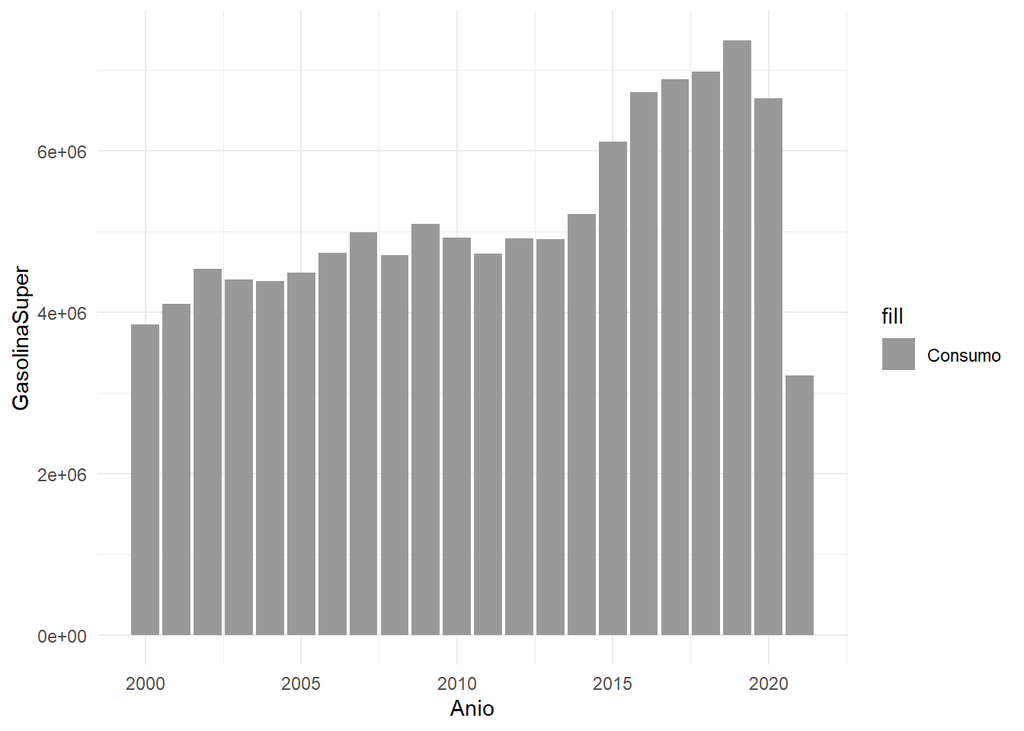

En la gráfica de barras se muestra el consumo total de cada año de gasolina super, se puede evidenciar que hay un crecimiento en casi todos los años, mientras que al comienzo parece no canviar relativamente mucho, al llegar al año al 2013-2014 hay un aumento significativo en el consumo, probablemente por el aumento parcial de vehiculos durante esos años, tambien se muestran los datos del 2021 (lo que va por el momento) y parece que el consumo llegara a ser bastante de nuevo.

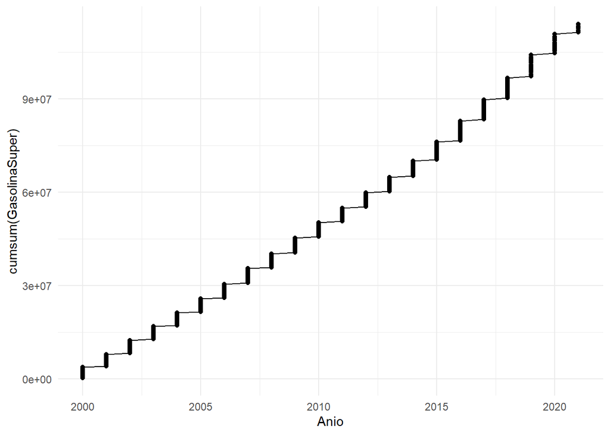

```r
df <- consumo[,c(2,4)]
p<-ggplot(df, aes(x=Anio, y=cumsum(GasolinaSuper))) + geom_line() + geom_point()
p
```

### Consumo de gasolina super por mes

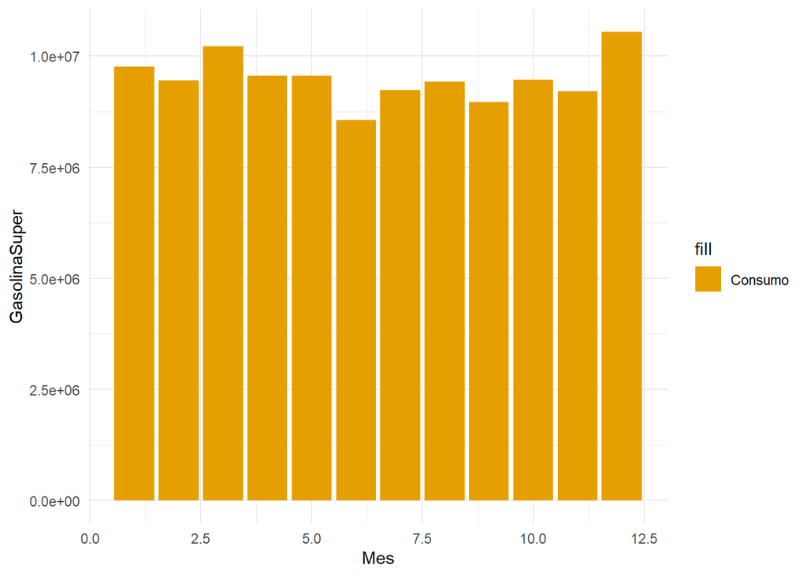

### Consumo de gasolina regular por año

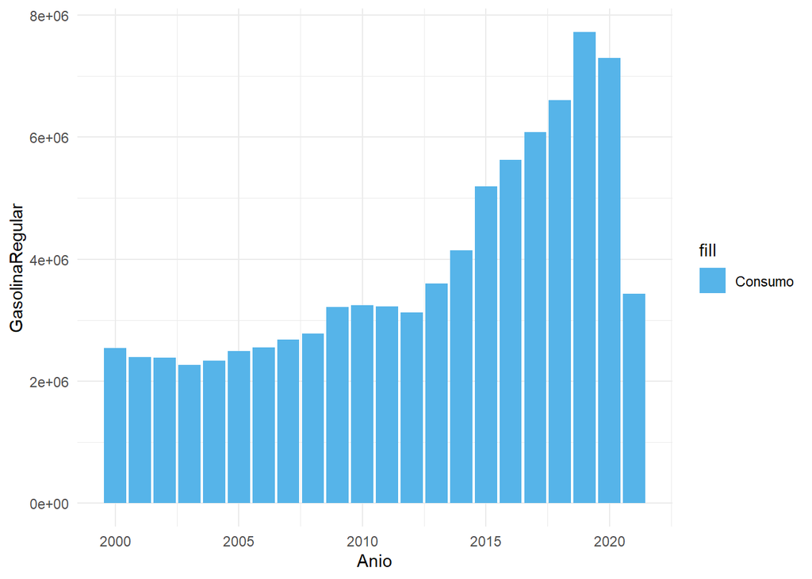

### Consumo de gasolina regular por mes

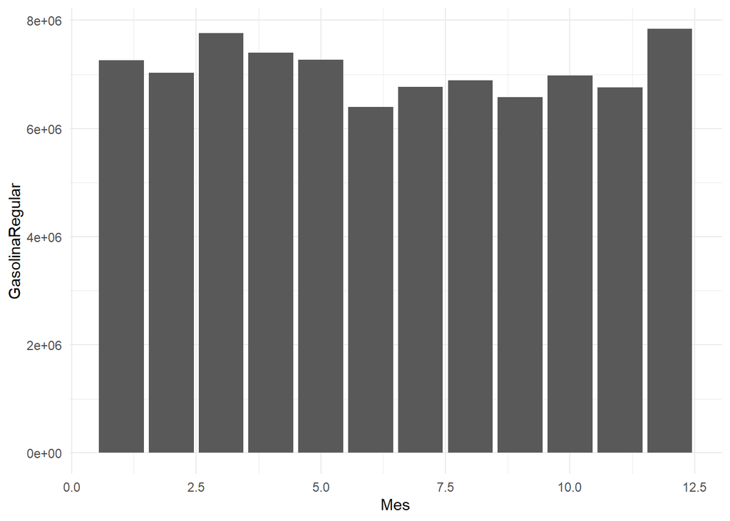

Observando la gráfica del consumo en cada mes a lo largo de los 21 años se puede notar (como en la gráfica de gasolina tipo super) que no existe realmente un cambio tan significativo en el consumo durante estos meses. De nuevo el mes que tiene más es diciemibre y el que tiene menos es junio. Por lo que parece ser que esos meses son donde hay mas y menos tránsido respectivamente en cada año.

### Consumo de gasolina Diesel por año

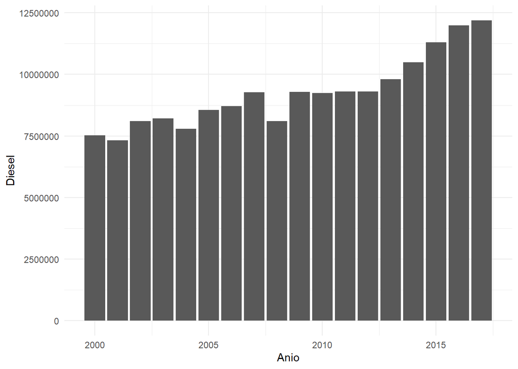

En el caso del Diesel el aumento en el consumo, a pesar de que sí existe, no es tan significativo con en la gasolina regular y un poco en la gasolina super. El aumento parcial comenzó de nuevo en el año 2013, por lo que pare lógico asumir que durante esos años (mayormente 2013-2014) comenzó a aumentar bastante la cantidad de vehiculos de cualquier tipo, resultado entonces en un aumento de consumo en todos los combustibles. Es importante mencionar que a partir del 2018 se comenzó a utilizar una “alternativa” de Diesel menos contaminante al ambiente conocida como Combustible Diesel bajo en zufre (DieselLS), por lo que a partir de ese año ya no existen registros de Diesel.

### Consumo de gasolina Diesel por mes

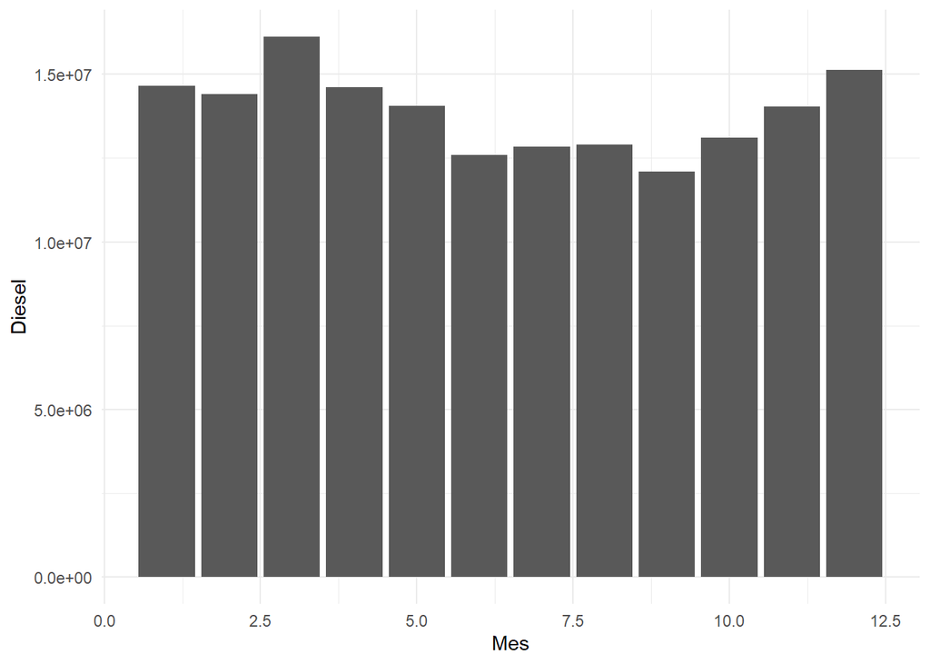

En la gráfica se puede observar el consumo de combustible Diesel en los meses durante los 21 años. De nuevo, a pesar de que no existen disminuciones abruptas, en el caso del Diesel, parece haber una descenso en el consumo en junio,julio,agosto y septiembre. Luego de estos meses, comienza a aumentar de nuevo.

## Importaciones

Ahora se analizarán sus proporciones en el set de datos de importaciones, que en base al consumo (la demanda) se espera que sea algo similar.

### Importación de gasolina super por año

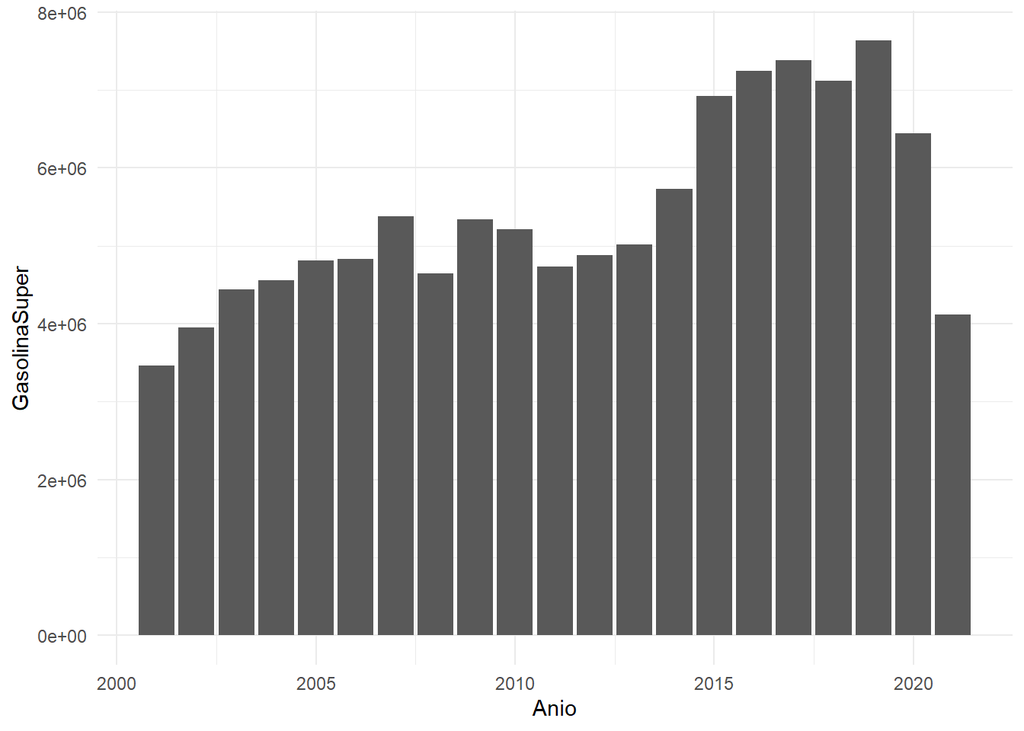

En esta gráfica se puede ver la tasa de importación de gasolina tipo super tiene un compartamiendo extremadamente similar a la grafica de super vs anio del set de datos de consumo, Se puede notar en este caso como al comienzo de los 2001 el aumento de la tasa de importanción aumenta lentamente llega a un intervalo relativamente estable y de nuevo en el 2013-2014 aumenta.

### Importación de gasolina super por mes

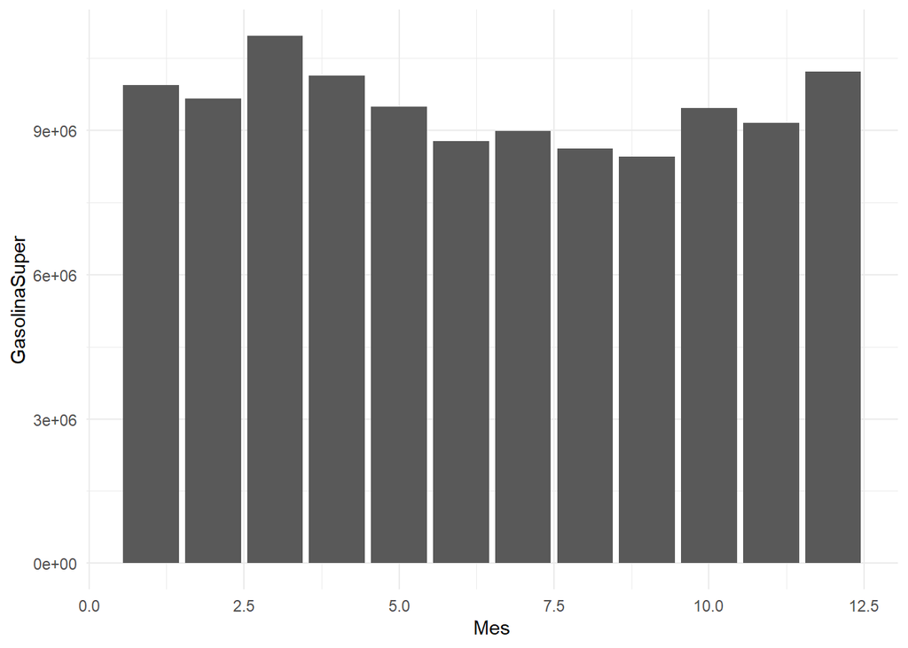

En la gráfica de impotación de gasolina super por mes se observa el comportamiento similar que el la gráfica de consumo, la cual tiene un comportamiento muy similar a lo largo de los meses. Sin embargo la importación máxima y mínima (Diciembre y junio respectivamente), varía levemente en esta gráfica, en donde marzo tiene más tasa de importación y septiembre la mínima.

### Importación de gasolina regular por año

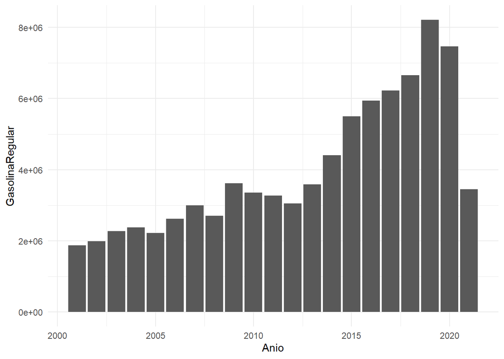

En el gráfico de importación de combustible anual se puede notar un comportamiento de crecimiento apresurado desde el año 2013, mismo comportamiento que en la gráfica de consumo.

### Importación de gasolina regular por mes

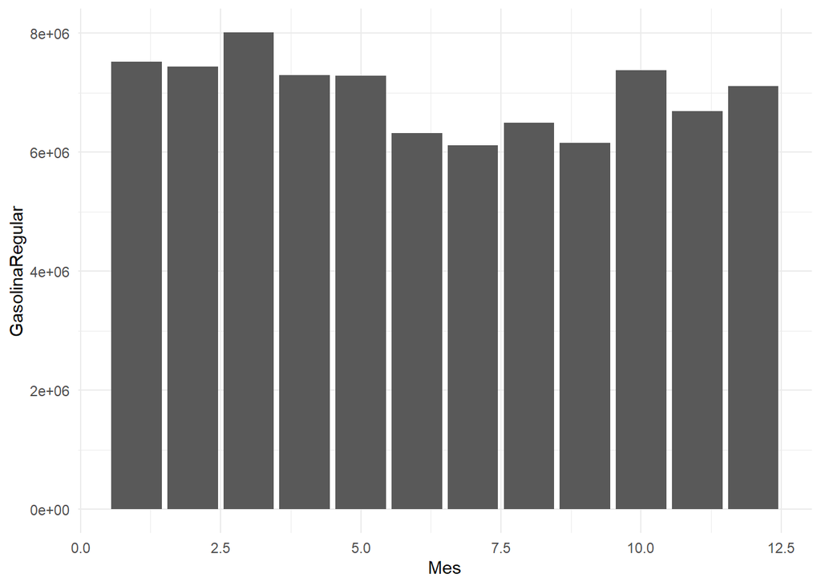

Como se puede evidenciar en el gráfico a pesar de que sigue existiendo una frecuencia de importación a corde con la gráfica de consumo respectiva. Sin embargo, de nuevo se muestra una diferencia entre el mínimo y el máximo, en donde en este caso hay dos mínimos, julio y septiembre, mientras que marzo sigue siendo el mes con más importación.

### Importación de gasolina Diesel por año

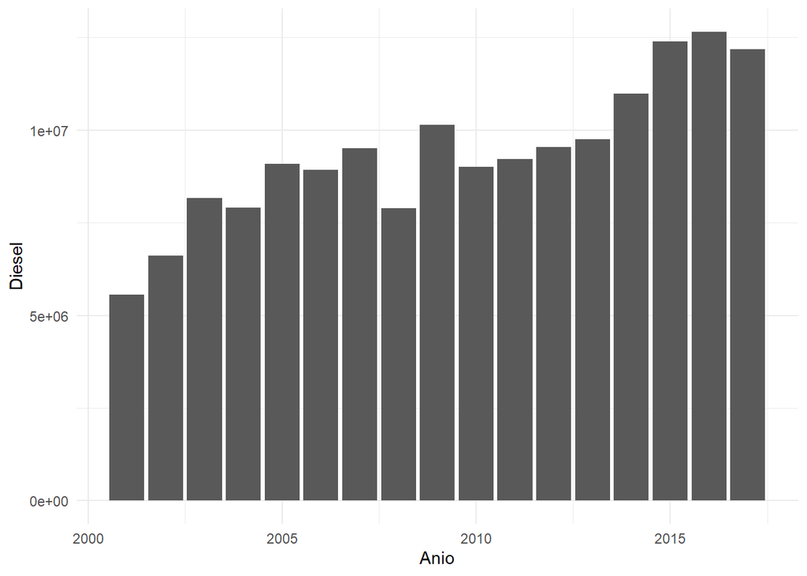

### Importación de gasolina Diesel por mes

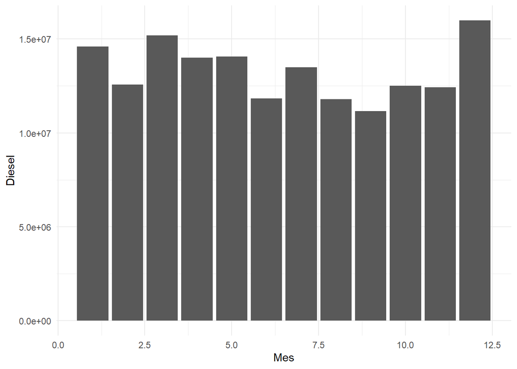

En su gráfica respectiva por mes, no hay ningún cambio significativo tampoco. En este caso Diciembre es el mes con más tasa de importación y septiembre el que tiene menos tasa.

### Importación de gasolina Diesel baja en azufre por año

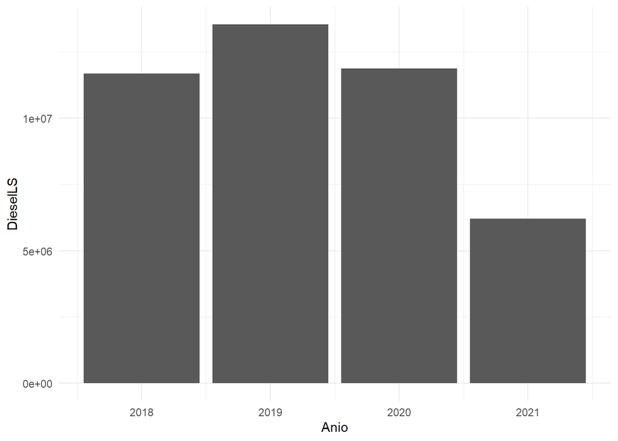

En la tasa de Diesel baja en azufre se ve que al momento que desde que se ha comenzado a implementar, ha tenido una importación muy similar en los años, con su pico en 2019. si vemos el eje y,y lo comparamos con el gráfico de Diesel anterior, se puede evidenciar que el consumo es muy similar a aquellos años despues del 2015, en 2020, a pesar de la pandemio, si hubo una importación notable.

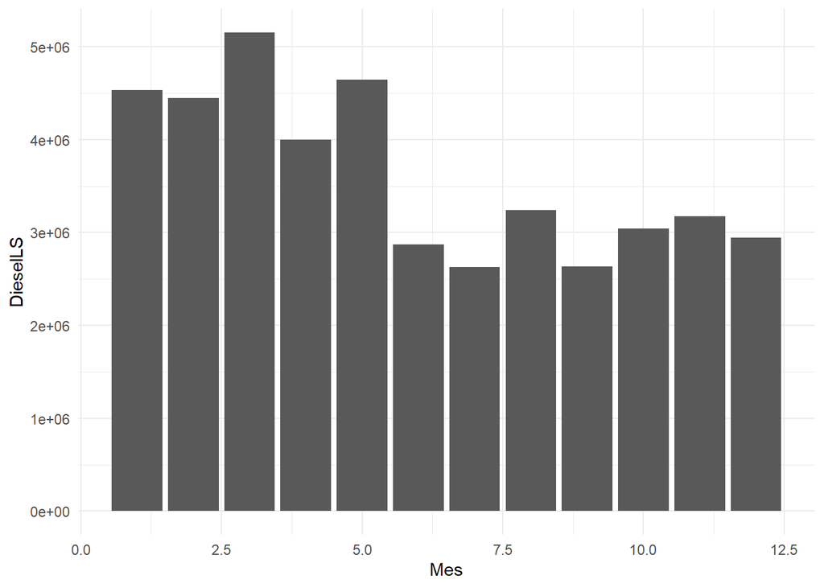

En la gráfica Se puede observar que los primeros meses, hasta mayo parece haber una importación mucho mayor a los meses siguientes. A partir de unio parece no haber muchos cambios en la cantidad de Diesel bajo en azufre exportado

### entre importación y consumo de gasolina super

[figure not shown]

## Pruebas de normalidad para cada tipo de gasolina en consumo

### consumo Gasolina Super

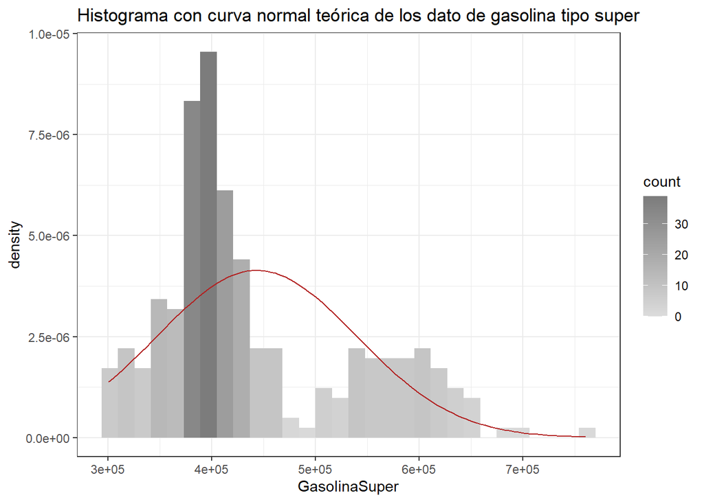

En el gráfico anterior se evidencia que el consumo de gasolina no cumple una distribución nomal, además de tener un sesgo muy notable a la izquierda, parecen formar dos conjuntos de datos.

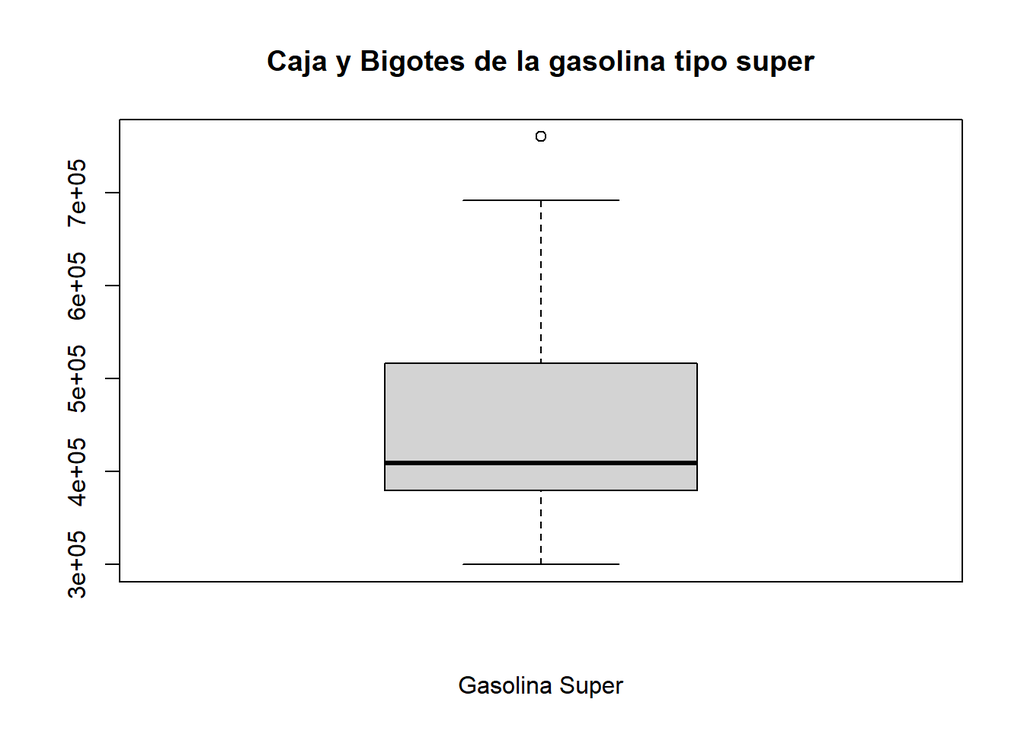

Observando el diagrama de caja y bigotes se peuede notar que hay una gran variabilidad entre la media y los demás datos, sin embargo, no existen tantos datos atípidos, ni por encima ni por debajo, por lo que en este diagrama si cumple normalidad.

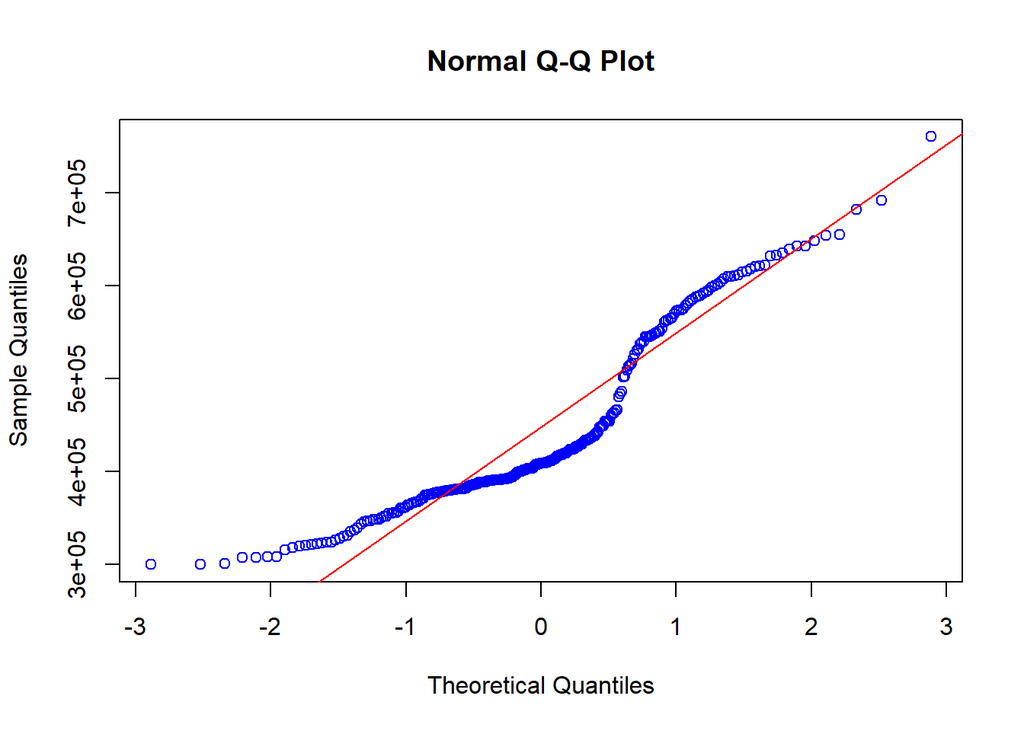

### Gasolina Regular

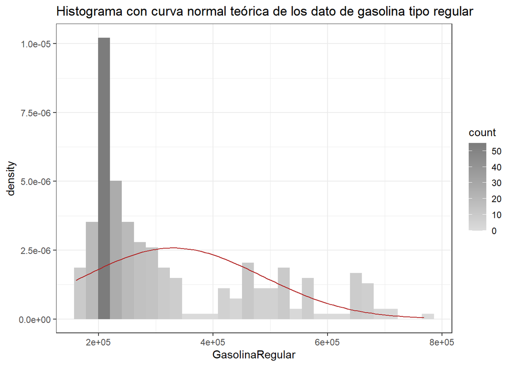

El el histograma del consumo de la gasolina tipo regular se puede notar un sesgo de nuevo muy marcado a la izquierda, este es de hecho, más evidente que en la gráfica anterior, además, cabe mencionar que la distribución de datos es mucho más dispersa, por lo que no cumple con la distribución normal según la capana de Gauss.

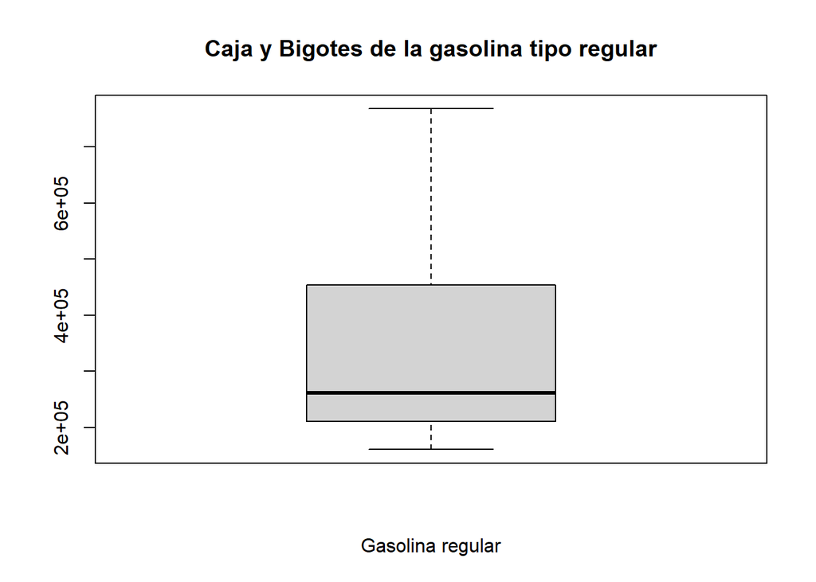

Observando el diagrama de caja y bigotes, nuevamente se puede ver que hay varios datos que se alejan significativamente de la media, más por encima que por debajo, pero niguno de ellos es atípico, por lo que si muestra normalidad.

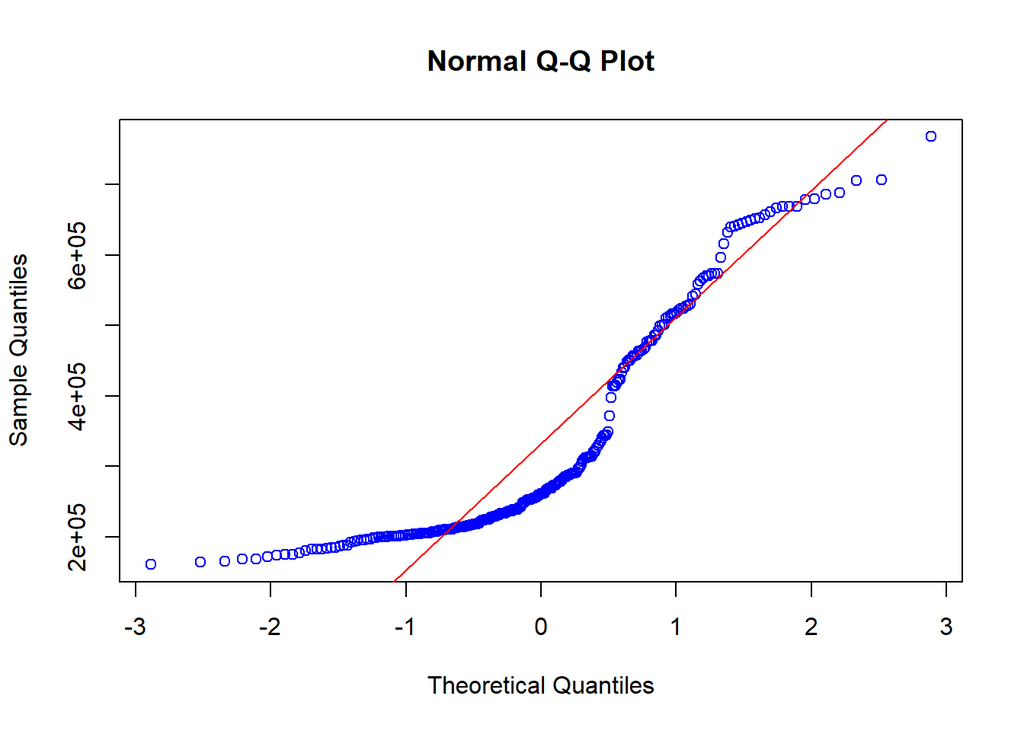

### Diesel

[figure not shown]

Para el Diesel en el set de datos de consumo, se puede notar que, al menos en el histograma no cumple con la normalidad. Se puede ver un sesgo a la izquierda y una gran cola a la derecha.

[figure not shown]

En el diagrama de caja y bigotes para el diesel se pueden notar más datos centrados en la media. Adicionalmente se ven muchos más puntos atípicos en este diagrama que en los anteriores, dificilmente se podría decir que cumple con normalidad.

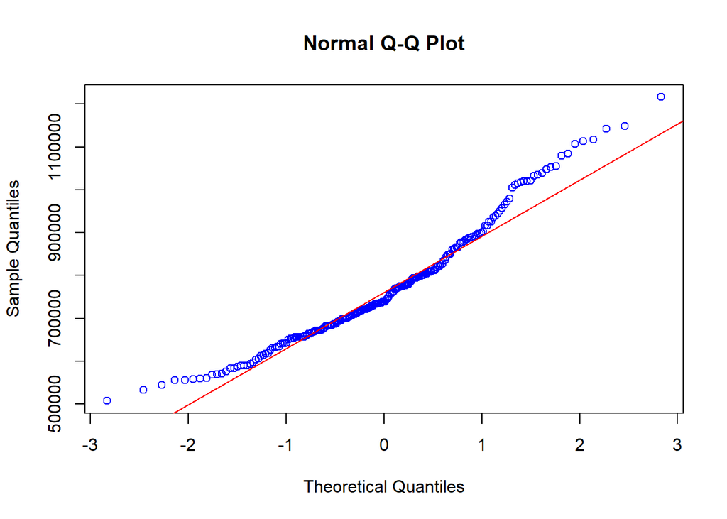

## Pruebas de normalidad para cada tipo de gasolina en importación

### Super

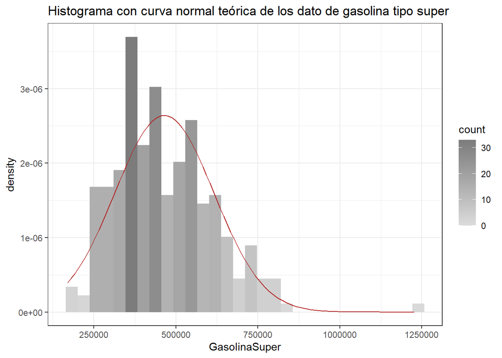

Comenzando con el histograma para el combustible importado, gasolina super. Es posible ver que, aunque no parece seguir una forma perfecta de campana de Gauss si tiene varios rasgos que parecen cumplir con normalidad bajo este criterio. Cabe mencionar que si hay un punto atípico que parece jalar la media(1250000).

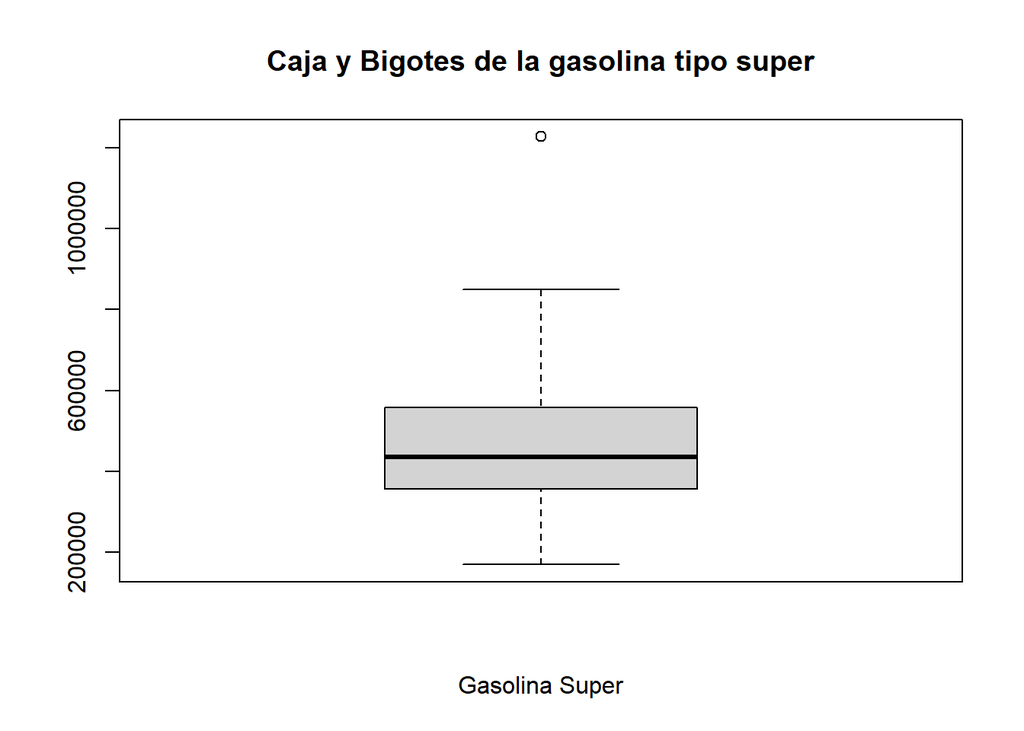

En el diagrama de caja y bigotes de la importación de la gasolina tipo super se puede observar que casi todos los datos parecen estar concentrados en un intervalo aceptable. Solo se ve un punto atípico por lo que si parece seguir una distribución normal.

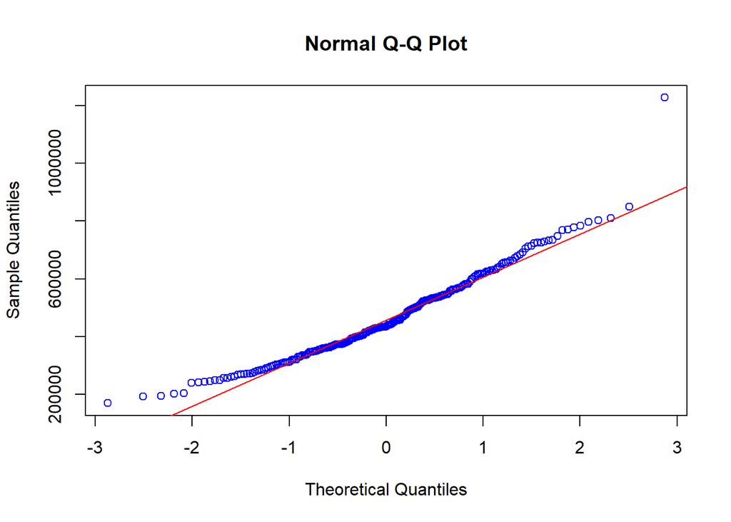

En e diagrama QQ normal es evidente que si sigue una distribución normal casi perfecta. esta variable cumple con las tres pruebas de normalidad.

### Regular

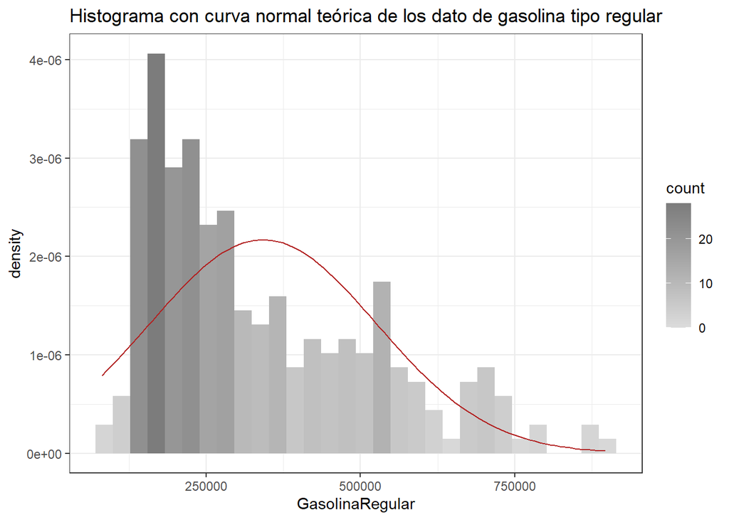

En este histograma se puede ver un sesgo a la izquierda y una gran distribución dispersa de datos referentes a la gasolina regular, por lo que no parece seguir una distribución normal.

[figure not shown]

Observando el gráfico de caja y bigotes se puede notar que hay varios datos que se encuentran sobre la media, sin mencionar del punto atípico, a pesar de eso, se puede decir que bajo este criterio si cumple con normalidad.

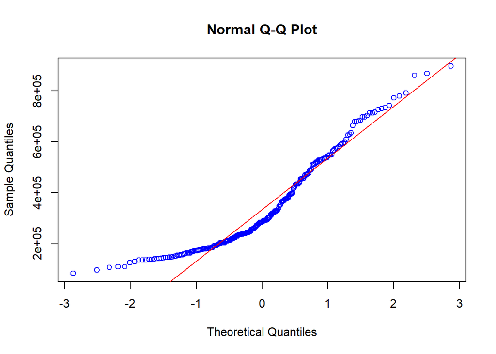